# SC Oklahoma County 00-19

Leticia, Fellow

Open Justice Oklahoma

2020-02-10

Background information: Why are we researching this topic? What is the expected product? A blog post? Analysis for an internal or external partner?

Using court data, this project aims to shed new light on the extent of the medical debt problem in Oklahoma.

# 1 Data sources

Where is the data from? The ojo database? OSCN? ODCR? Crime in Oklahoma reports?

The data is from the ojo database and OSCN.

## 1.1 Timeframe

What years/months are you looking at? Year of case filing, first disposition, prison admission, etc.? Be as specific as possible.

The analysis aims to identify trends in medical debt cases over the past 20 years (2000-2019).

## 1.3 Variables

What variables did you use? What types of cases, crimes, etc.?

Debt collections in the state’s District Court.

## 1.4 Query

If you’re using data from the OJO database, include the query you used to pull your data. This may be a function that starts `ojo_query_` or `dbGetQuery`.

```r
sc <- ojo_query_disps("OKLAHOMA", "SC", 2000:2019)
```

# 2 Checking Data

Explain the results of the checks of your data.

The data is 99-100% complete.

## 2.1 Check for Completeness

If you’re using court data, you can use the `ojo_check_comp` to see how complete the data is.

```r
ojo_check_comp(sc)
```

[output not shown]

## 2.2 Check for NAs

Detail the NAs and blank items in your data and, if necessary and possible, fill them in.

A large portion of the “iss_plaint” data for the early 2000s is missing.

```r
nas <- sc %>%
  group_by(casenum) %>%
  filter(all(is.na(iss_plaint) | iss_plaint == ""))
```

# 3 Defining Measures

This is where you’ll likely spend the biggest chunk of time if you’re using court data. There are a lot of ways things can go wrong, so we want to be able to trace back all of our steps and document all the decisions we’re making.

Because each analysis project is a bit different, the number and length of subsections in this section will vary a lot.

```r
sc %>%
  count(iss_desc) %>%
  arrange(desc(n))
```

```
## # A tibble: 113 x 2
##    iss_desc                                    n
##    <chr>                                   <int>
##  1 "FORCIBLE ENTRY & DETAINER"            309479
##  2 "INDEBTEDNESS"                         197112
##  3 "INDEBTEDNESS >$1500."                  52262
##  4 "FORCIBLE ENTRY & DETAINER >$1500."     17222
##  5 ""                                       2370
##  6 "INDEBTEDNESS >$5000.00."                1906
##  7 "BREACH AGREEMENT - CONTRACT"            1420
##  8 "BREACH AGREEMENT - CONTRACT>$1500."      718
##  9 "AFFIDAVIT FOR REPLEVIN"                  451
## 10 "FORCIBLE ENTRY & DETAINER >$5000.00."    355
## # … with 103 more rows
```

```r
debt <- sc %>%
  filter(!str_detect(iss_desc, "FORC|PROMISSORY|REPLEVIN|BREACH"))

debt %>%
  count(iss_desc) %>%
  arrange(desc(n))
```

```
## # A tibble: 89 x 2
##    iss_desc                             n
##    <chr>                            <int>
##  1 "INDEBTEDNESS"                  197112
##  2 "INDEBTEDNESS >$1500."           52262
##  3 ""                                2370
##  4 "INDEBTEDNESS >$5000.00."         1906
##  5 "INTERPLEADER"                     215
##  6 "AUTOMOBILE NEGLIGENCE >$1500."    197
##  7 "DAMAGES >$1500.00"                129
##  8 "DAMAGES"                          116
##  9 "ASSAULT & BATTERY"                112
## 10 "INTERPLEADER >$1500.00"            86
## # … with 79 more rows
```

```r
debt <- debt %>%
  filter(str_detect(iss_desc, "DEBT"))

debt %>%
  count(iss_desc) %>%
  arrange(desc(n))
```

```
## # A tibble: 13 x 2
##    iss_desc                     n
##    <chr>                    <int>
##  1 INDEBTEDNESS            197112
##  2 INDEBTEDNESS >$1500.     52262
##  3 INDEBTEDNESS >$5000.00.   1906
##  4 INDEBTEDNESS < 1500.00       8
##  5 INDEBTEDNESS <1500.00        4
##  6 INDEBTEDNESS <1500.          1
##  7 INDEBTEDNESS <1500.000       1
##  8 INDEBTEDNESS UNDER 1500      1
##  9 INDEBTEDNESS< 1500.          1
## 10 INDEBTEDNESS<1500.00         1
## 11 INDEBTEDNESS>$1500.          1
## 12 INDEBTNESS                   1
## 13 INDEBTNESS 1                 1
```

```r
debt %>%
  count(iss_plaint) %>%
  arrange(desc(n))
```

```
## # A tibble: 27,194 x 2
##    iss_plaint                                  n
##    <chr>                                   <int>
##  1 ""                                      36821
##  2 "INTEGRIS BAPTIST MEDICAL CENTER INC"    6189
##  3 "CAMELOT FINANCIAL SERVICES INC"         6068
##  4 "INTEGRIS SOUTHWEST MEDICAL CENTER INC"  2986
##  5 "CITY NATIONAL BANK"                     2838
##  6 "CUSTOMER CREDIT CORP"                   2565
##  7 "COURTESY LOANS"                         2553
##  8 "WEOKIE CREDIT UNION"                    2511
##  9 "CONVENIENT LOANS"                       2484
## 10 "EMERGENCY MEDICAL SERVICES AUTHORITY"   2472
## # … with 27,184 more rows
```

```r
debt <- debt %>%
  mutate(plaint_type = case_when(str_detect(iss_plaint, "HEALTH|CLINIC|MEDICAL|HOSPITAL|SURGICARE|INTEGRIS\\sAMBULATORY|COMPREHENSIVE\\sTHERAPY|CARDIOLOGY|TERENCE\\sC\\sTOFT\\sDDS|DENTIST|FOOT\\sAND\\sANKLE|DENTAL|SURGERY|ORTHOPEDICS|INTEGRIS|ALLIED\\sPHYSICIANS\\sGROUP|SURGICAL|D\\.D\\.S\\.|ADVANCES\\sIN\\sDENTISTRY|MANORCARE|ANESTHESIOLOGY|OU\\sPHYSICIANS|PULMONARY|PHARMACEUTICALS|PHYSICAL\\sTHERAPY|RADIOLOGY| DDS|COMPREHENSIVETHERAPY|PEDIATRICS|MRI") ~ "MEDICAL",
                                 str_detect(iss_plaint, "BANK|FCU|CREDIT|LOAN|FINANCIAL|WORLD\\sACCEPTANCE|INVESTMENT|FINANCE|MONEY|MOTORS|CASH|B\\s&\\sF|PROFESSIONAL\\sINSURANCE\\sAGENCY\\sCORP|SOUTHWESTERN\\sBELL\\sYELLOW\\sPAGES|SINGLETON\\sENTERPRISES|B&F|B\\sAND\\sF|MANHATTAN\\sMANAGEMENT\\sCOMPANY|ROYAL\\sPRESTIGE|BONDS|TELEPHONE|DEPARTMENT\\sSTORES|AUTO|HOME|ADVANCE\\sAMERICA|STATE\\sOF\\sOKLAHOMA|ROCK\\sKNOLL\\sASSOCIATION|B&\\sF|ELECTRIC|RENT\\sA\\sCENTER|LIBERTY\\sBONDING|DEPARTMENT\\sOF\\sTRANSPORTATION") ~ "OTHER",
                                 TRUE ~ "UNKNOWN"))

debt %>%
  count(plaint_type) %>%
  arrange(desc(n))
```

```
## # A tibble: 3 x 2
##   plaint_type      n
##   <chr>        <int>
## 1 OTHER       132205
## 2 UNKNOWN      85614
## 3 MEDICAL      33481
```

```r
debt %>%
  filter(plaint_type == "UNKNOWN") %>%
  count(iss_plaint) %>%
  arrange(desc(n))
```

```
## # A tibble: 23,560 x 2
##    iss_plaint                                               n
##    <chr>                                                <int>
##  1 ""                                                   36821
##  2 "W.CRAIG BARTON"                                       996
##  3 "GARCIA INC"                                           425
##  4 "VALUED SERVICES OF OKLAHOMA LLC"                      238
##  5 "THE BOARD OF REGENTS OF THE UNIVERSITY OF OKLAHOMA"   222
##  6 "WILSON-BREIT, INC"                                    150
##  7 "ASKINS, J B"                                          138
##  8 "STARVIEW LLC"                                         111
##  9 "RICHARDSON-GADDIS, MONICA"                             99
## 10 "RENT-A-CENTER"                                         94
## # … with 23,550 more rows
```

```r
debt %>%
  count(plaint_type) %>%
  arrange(desc(n))
```

```
## # A tibble: 3 x 2
##   plaint_type      n
##   <chr>        <int>
## 1 OTHER       132205
## 2 UNKNOWN      85614
## 3 MEDICAL      33481
```

```r
debt %>%
  filter(plaint_type == "MEDICAL") %>%
  count(iss_plaint) %>%
  arrange(desc(n))
```

```
## # A tibble: 869 x 2
##    iss_plaint                                             n
##    <chr>                                              <int>
##  1 INTEGRIS BAPTIST MEDICAL CENTER INC                 6189
##  2 INTEGRIS SOUTHWEST MEDICAL CENTER INC               2986
##  3 EMERGENCY MEDICAL SERVICES AUTHORITY                2472
##  4 INTEGRIS SOUTH OKLAHOMA CITY HOSPITAL CORP          1302
##  5 INTEGRIS SOUTH OKLAHOMA CITY HOSPITAL CORP D/B/A I  1105
##  6 INTEGRIS BAPTIST MEDICAL CENTER, INC.               1061
##  7 INTEGRIS BAPTIST MEDICAL CENTER                     1055
##  8 OKLAHOMA SURGICARE                                   909
##  9 INTEGRIS SOUTHWEST MEDICAL CENTER                    814
## 10 ST ANTHONY HOSPITAL                                  769
## # … with 859 more rows
```

```r
debt <- debt %>%
  filter(plaint_type == "MEDICAL")
```

# 4 Summarizing and Visualizing Data

There will likely be several sections here too. Summarize and visualize the data in different ways and identify trends that you see.

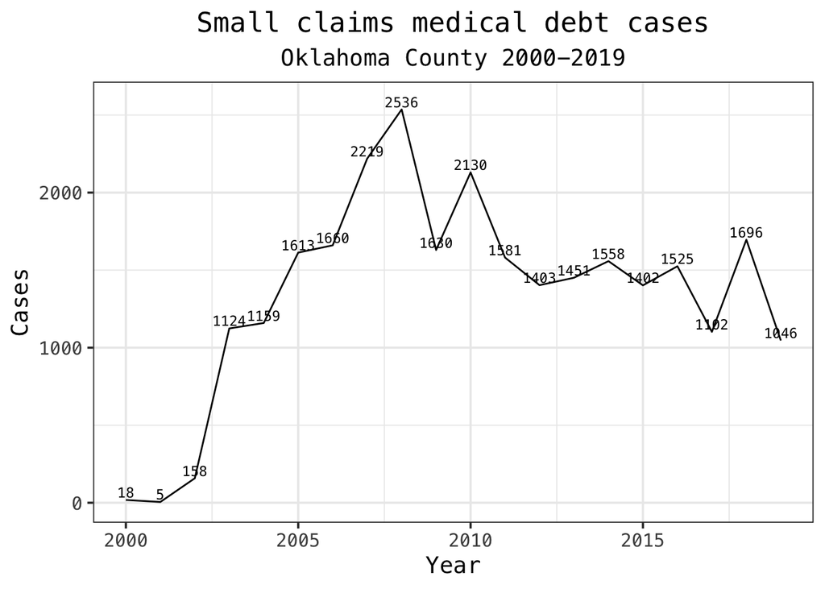

```r
debt <- debt %>%
  group_by(casenum) %>%
  slice(1)

year_sum <- debt %>%
  ungroup %>%
  count(file_year)

ggplot(year_sum, aes(file_year, n)) +
  geom_line() +
  geom_text(aes(y = n + 50, label = n), family = "Menlo", size = 3) +
  xlab("Year") + ylab("Cases") +
  ylim(0, NA) + # Extends y-axis down to zero
  theme_ojo() +
  theme(plot.title = element_text(hjust = 0.5)) +
  theme(plot.subtitle = element_text(hjust = 0.5)) +
  labs(title = "Small claims medical debt cases",
       subtitle = "Oklahoma County 2000-2019")
```

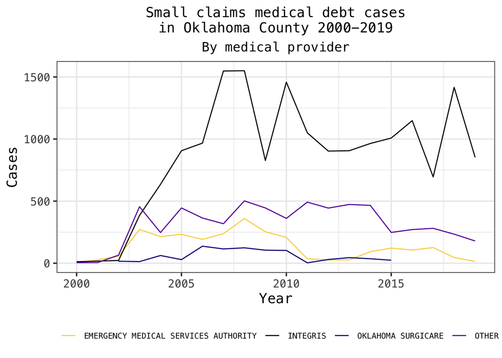

```r
debt <- debt %>%
  mutate(plaint_cat = case_when(str_detect(iss_plaint, "INTEGRIS") ~ "INTEGRIS",
                                str_detect(iss_plaint, "EMERGENCY MEDICAL SERVICES AUTHORITY") ~ "EMERGENCY MEDICAL SERVICES AUTHORITY",
                                str_detect(iss_plaint, "OKLAHOMA SURGICARE") ~ "OKLAHOMA SURGICARE",
                                TRUE ~ "OTHER"))

plaint_sum <- debt %>%
  ungroup %>% # Our data frame is still grouped by casenum from the code above; ungroup to summarize using broader groups
  count(file_year, plaint_cat)

ggplot(plaint_sum, aes(file_year, n, group = plaint_cat, color = plaint_cat)) +
  geom_line() +
  xlab("Year") + ylab("Cases")+
  ylim(0, NA) + # Extends y-axis down to zero
  theme_ojo() + # Adds ojo styling to the plot
  theme(legend.title=element_blank())+
  theme(plot.title = element_text(hjust = 0.5, size = 14)) +
  theme(plot.subtitle = element_text(hjust = 0.5, size = 13)) +
  theme(legend.text=element_text(size = 8))+
  theme(legend.position="bottom")+
  labs(title = "Small claims medical debt cases\nin Oklahoma County 2000-2019",
       subtitle = "By medical provider") +
  scale_color_manual(values = ojo_pal) # Gives lines colors from ojo's palette
```